# Jonathan Nusantara (jan265)

#### Next, we explored on how Principal Component Analysis (PCA) can impact the training and testing time and accuracy. For 3 nearest neighbor, we experimented to train the model on just part of training set and also trying PCA. The first two models are on training and testing on one-third and one-fifth of the data. The last three models are on training with the data after performing PCA with n = 10, 20, and 40. The n input is the variable to choose how many principal components do we want to choose. The tradeoff is that more components will allow us to have higher variance, but it means that we will need more storage and more computation. As a result, the number of components chosen needs to be tweaked, to ideally be a low value that still has a high variance (>90%). We will analyze the difference in train and test time and accuracy.

```
Training time 3.858 seconds
Test time 74.243 seconds
Test score with 3NN is: 0.9613
Confusion matrix, without normalization
```

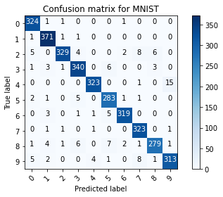

```python
# rescale training and testing
first_index = int(60000/3)
second_index = int(60000/3+10000/3)
X_train, X_test = X[:first_index], X[first_index:second_index]
y_train, y_test = y[:first_index], y[first_index:second_index]

start_time = time.time()
KNN3 = KNeighborsClassifier(n_neighbors=3)

#Train the classifier
KNN3.fit(X_train,y_train)
train_time_knn_1 = time.time() - start_time
print("Training time %.3f seconds" % train_time_knn_1)

#Evaluate the result
start_time = time.time()
score_knn_1 = KNN3.score(X_test,y_test)
test_time_knn_1 = time.time() - start_time
print("Test time %.3f seconds" % test_time_knn_1)
print("Test score with 3NN is: %.4f" % score_knn_1)

#Confusion Matrix
y_predict = KNN3.predict(X_test)
cfm = confusion_matrix(y_test, y_predict)
plot_confusion_matrix(cfm, classes=range(10), title='Confusion matrix for MNIST')
```

```
Training time 1.448 seconds
Test time 25.407 seconds
Test score with 3NN is: 0.9460
Confusion matrix, without normalization
```

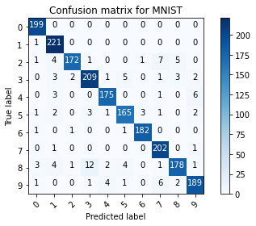

```python
# rescale training and testing
first_index = int(60000/5)
second_index = int(60000/5+10000/5)
X_train, X_test = X[:first_index], X[first_index:second_index]
y_train, y_test = y[:first_index], y[first_index:second_index]

start_time = time.time()
KNN3 = KNeighborsClassifier(n_neighbors=3)

#Train the classifier
KNN3.fit(X_train,y_train)
train_time_knn_2 = time.time() - start_time
print("Training time %.3f seconds" % train_time_knn_2)

#Evaluate the result
start_time = time.time()
score_knn_2 = KNN3.score(X_test,y_test)
test_time_knn_2 = time.time() - start_time
print("Test time %.3f seconds" % test_time_knn_2)
print("Test score with 3NN is: %.4f" % score_knn_2)

#Confusion Matrix
y_predict = KNN3.predict(X_test)
cfm = confusion_matrix(y_test, y_predict)
plot_confusion_matrix(cfm, classes=range(10), title='Confusion matrix for MNIST')
```

```
Training time 0.404 seconds
Test time 6.965 seconds
Test score with 3NN is: 0.9689
Confusion matrix, without normalization
```

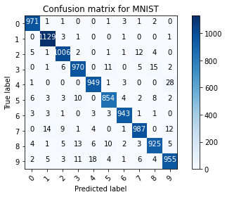

```python
# rescale training and testing
first_index = int(60000/1)
second_index = int(60000/1+10000/1)
X_train, X_test = X[:first_index], X[first_index:second_index]
y_train, y_test = y[:first_index], y[first_index:second_index]

pca = PCA(n_components=20)
pca.fit(X_train, y_train)

start_time = time.time()
KNN3 = KNeighborsClassifier(n_neighbors=3)
KNN3.fit(pca.transform(X_train),y_train)
train_time_knn_3 = time.time() - start_time
print("Training time %.3f seconds" % train_time_knn_3)

#Evaluate the result
start_time = time.time()
score_knn_3 = KNN3.score(pca.transform(X_test),y_test)
test_time_knn_3 = time.time() - start_time
print("Test time %.3f seconds" % test_time_knn_3)
print("Test score with 3NN is: %.4f" % score_knn_3)

#Confusion Matrix
y_predict = KNN3.predict(pca.transform(X_test))
cfm = confusion_matrix(y_test, y_predict)
plot_confusion_matrix(cfm, classes=range(10), title='Confusion matrix for MNIST')
```

```
Training time 0.528 seconds
Test time 20.061 seconds
Test score with 3NN is: 0.9745
Confusion matrix, without normalization
```

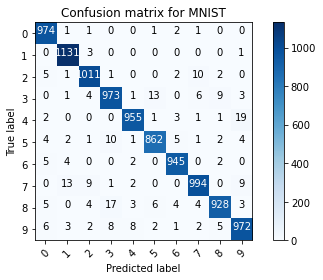

```python
pca = PCA(n_components=40)
pca.fit(X_train, y_train)

start_time = time.time()
KNN3 = KNeighborsClassifier(n_neighbors=3)
KNN3.fit(pca.transform(X_train),y_train)
train_time_knn_4 = time.time() - start_time
print("Training time %.3f seconds" % train_time_knn_4)

#Evaluate the result
start_time = time.time()
score_knn_4 = KNN3.score(pca.transform(X_test),y_test)
test_time_knn_4 = time.time() - start_time
print("Test time %.3f seconds" % test_time_knn_4)
print("Test score with 3NN is: %.4f" % score_knn_4)

#Confusion Matrix
y_predict = KNN3.predict(pca.transform(X_test))
cfm = confusion_matrix(y_test, y_predict)
plot_confusion_matrix(cfm, classes=range(10), title='Confusion matrix for MNIST')
```

```
Training time 0.365 seconds
Test time 1.652 seconds
Test score with 3NN is: 0.9245
Confusion matrix, without normalization
```

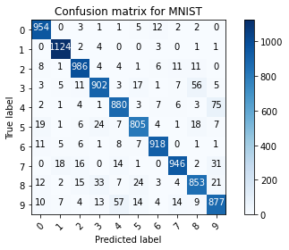

```python
pca = PCA(n_components=10)
pca.fit(X_train, y_train)

start_time = time.time()
KNN3 = KNeighborsClassifier(n_neighbors=3)
KNN3.fit(pca.transform(X_train),y_train)
train_time_knn_5 = time.time() - start_time
print("Training time %.3f seconds" % train_time_knn_5)

#Evaluate the result
start_time = time.time()
score_knn_5 = KNN3.score(pca.transform(X_test),y_test)
test_time_knn_5 = time.time() - start_time
print("Test time %.3f seconds" % test_time_knn_5)
print("Test score with 3NN is: %.4f" % score_knn_5)

#Confusion Matrix
y_predict = KNN3.predict(pca.transform(X_test))
cfm = confusion_matrix(y_test, y_predict)
plot_confusion_matrix(cfm, classes=range(10), title='Confusion matrix for MNIST')
```

```python
table = [["1/3 of data set",train_time_knn_1,test_time_knn_1,score_knn_1],["1/5 of data set",train_time_knn_2,test_time_knn_2,score_knn_2],["PCA n=20",train_time_knn_3,test_time_knn_3,score_knn_3],["PCA n=40",train_time_knn_4,test_time_knn_4,score_knn_4],["PCA n=10",train_time_knn_5,test_time_knn_5,score_knn_5]]
print(tabulate(table, headers=["Training Set","Train time (s)", "Test time (s)", "Score"]))
```

```
Training Set       Train time (s)    Test time (s)     Score
---------------  ----------------  ---------------  --------
1/3 of data set          3.85778          74.243    0.961296
1/5 of data set          1.44792          25.4075   0.946
PCA n=20                 0.40419           6.96527  0.9689
PCA n=40                 0.527591         20.0614   0.9745
PCA n=10                 0.365155          1.65223  0.9245
```